# Financial Viability Analysis

Vicky Wang (viwa)

2024-04-09

**Profitability of patients from Cardiac and Orthopedic services**

Table of Average Gross Margin, Calculated on Total Pay and Direct Cost Values for each Service Type

| Type of Service | Average Gross Margin (%) |
| --- | --- |
| Cardiology | 115.47 |
| Orthopedics | 92.70 |
| Other | 118.22 |

Average Gross Margin by Service Type

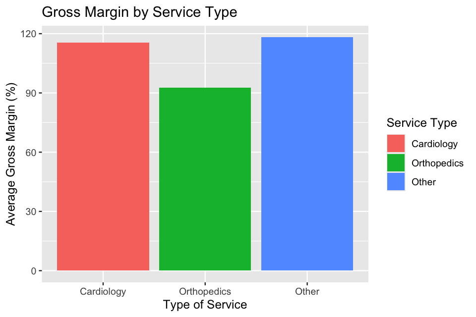

**LOS Outliers** Plot of Non-Outliers vs Outliers in Length of Stay by their Service Types

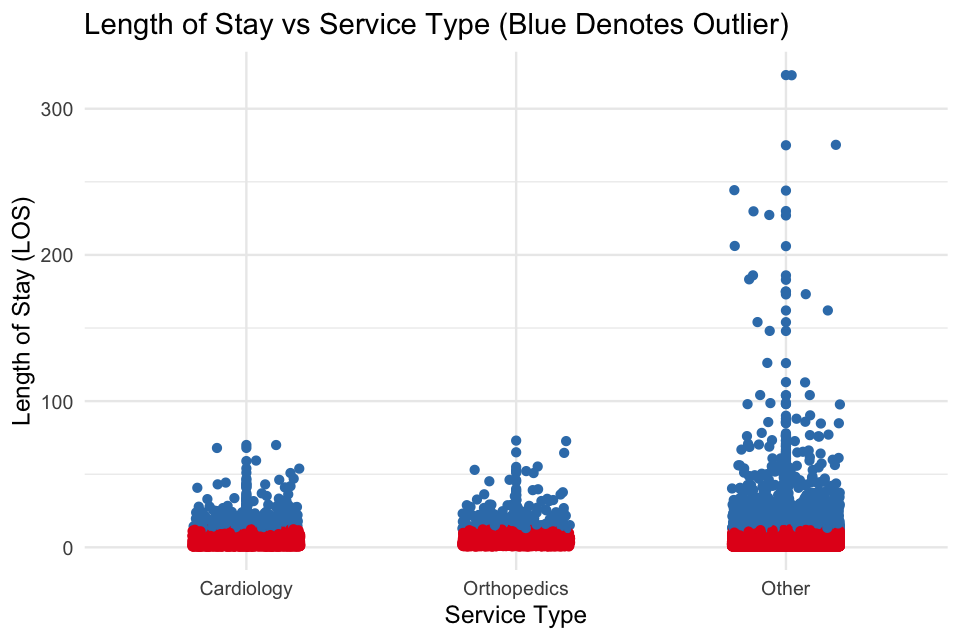

Table of Proportion of Outliers in Length of Stay for each Service Type

| Service Type | Proportion of Outliers per Type |
| --- | --- |
| Cardiology | 0.09 |
| Orthopedics | 0.11 |
| Other | 0.09 |

**Payer mix**

1. Pie chart of the overall summary of primary payors, regardless of major diagnostic category group.

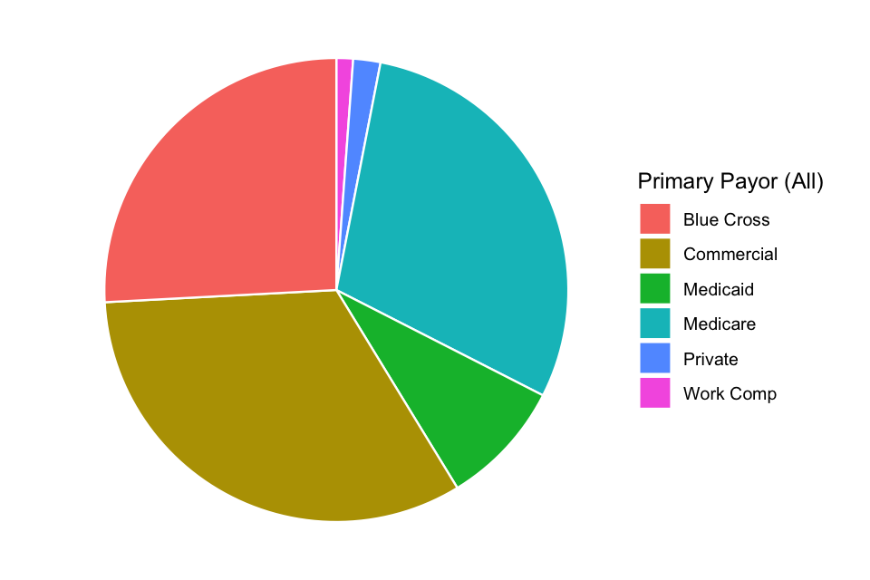

Most patient encounters are paid for by the Blue Cross, Commercial payors, or Medicare. Medicaid represents a smaller proportion, and Private/Work Comp insurers are least frequent.

2. Summary of Primary Payors for Cardiology Services

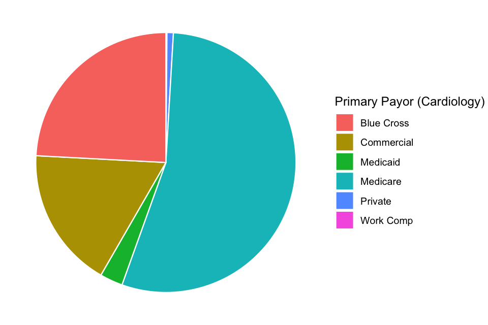

Most (50%) cardiology-service patient encounters are paid using Medicare.

3. Summary of Primary Payors for Orthopedics Services.

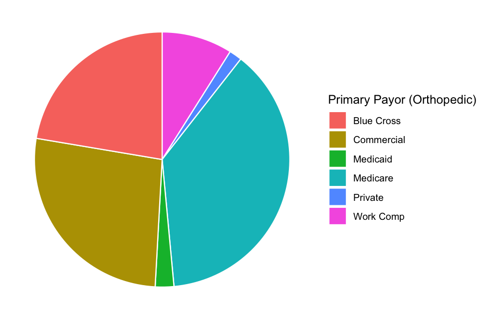

Most orthopedic-service patient encounters are paid using Medicare.

4. Summary of Primary Payors for all Other Services.

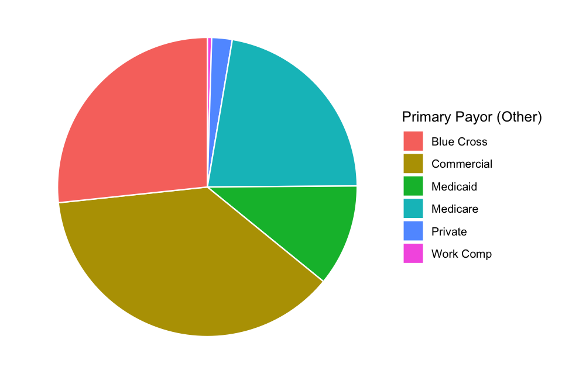

Most non-cardiology or non-orthopedic services are paid for using commercial insurers.

**Rates of emergent vs. elective care**

Bar Graph of Admission Type, Separated by Service Type

| Service Type | Type of Care | Proportion per Type |
| --- | --- | --- |
| Cardiology | ELECTIVE | 0.143 |
| Cardiology | EMERGENT | 0.857 |
| Orthopedics | ELECTIVE | 0.616 |
| Orthopedics | EMERGENT | 0.384 |
| Other | ELECTIVE | 0.467 |
| Other | EMERGENT | 0.533 |

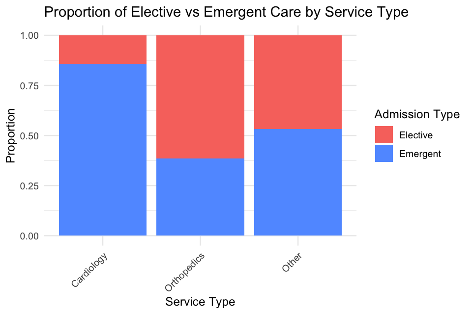

**Probable future demand given Omega’s patient demographics for Cardiac and Orthopedic services** (this is less of a coding/query question, and more of discussing what you can an infer from demographics and trends)

Number of Patients, Separated by Age Group and Service Type

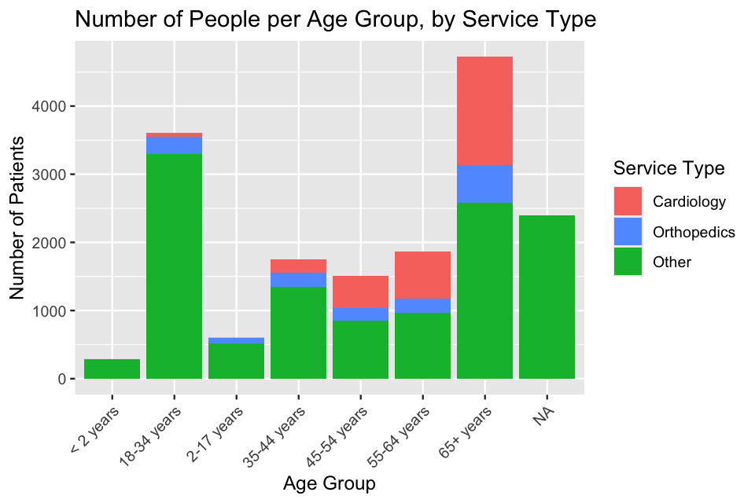

Number of Patients, Separated by Race and Service Type

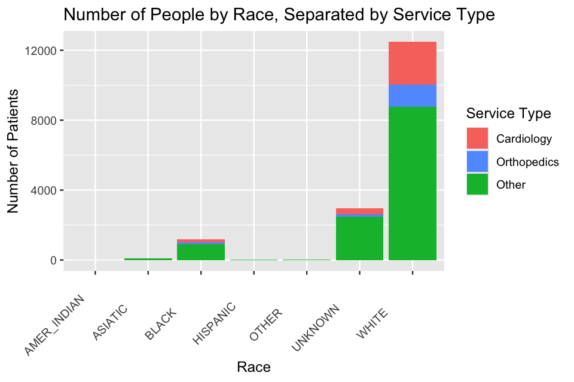

Number of Patients, Separated by Sex and Service Type

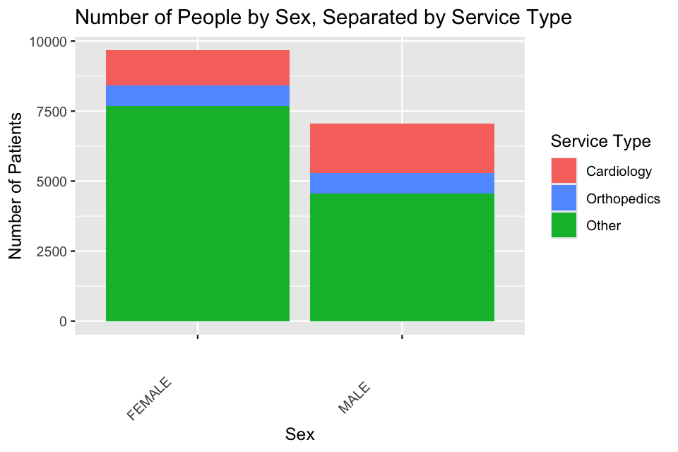

Number of Patients, Separated by RACE, AGE GROUP, SEX, and Service Type

[output not shown]

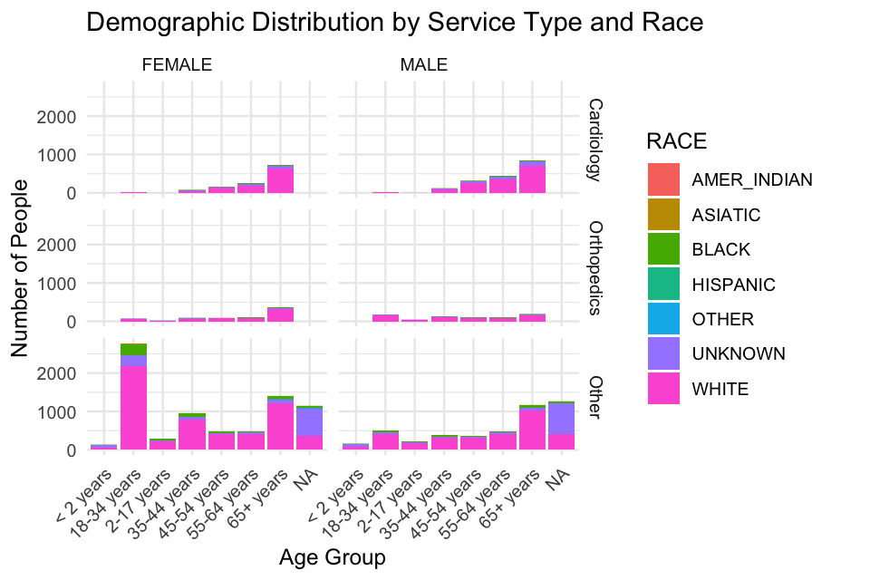

Number of Patients of each Service Type over Aug 1999 - Dec 2000

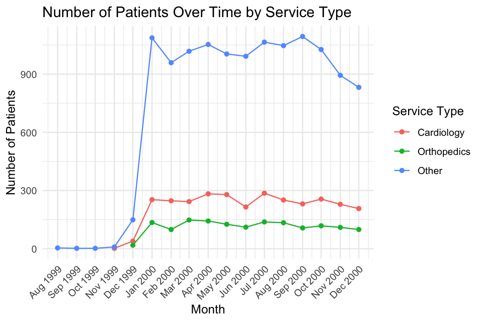